# Zimbabwe Trust Index

Summary

This page presents additional analysis of survey data collected by the Zimbabwe Red Cross (ZRCS) in the fall 2023, covering questions around trust as part of the Community Trust Index project.

# Sampling

## Coverage

The sampling focused on areas around three health centers and clinics in the Shamva district. Volunteers from the ZRCS were recruited to conduct the data collection. The sampling approach can be considered a simple random sample, where a random walk approach has been used. The selection of the clinics and health center was made to ensure availability of volunteers and due to logistical reasons.

Therefore, all the data should be regarded as indicative, and it is strongly advised against presenting this data as representative of the entire country of Zimbabwe, as the convenience sampling approach of the clinics taken does not allow for drawing generalizations for the population in Zimbabwe, despite the random sample of people around the clinics and health centers.

[interactive chart not shown]

For the following demographic data, we show the full data set including people who indicated to volunteered for the ZRCS as well as those who benefited from the ZRCS.

## Gender and Age

The following data shows the breakdown of the sample by gender and age. The male/female ratio of the sample (0.46) shows an important over-representation of females compared to the national population distribution in Zimbabwe(0.82).

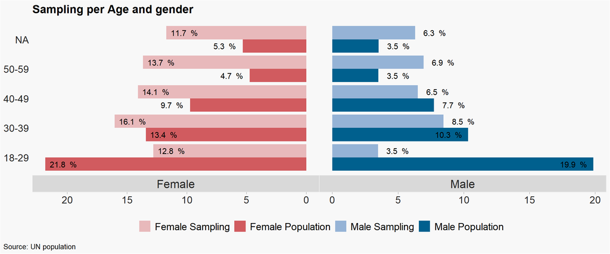

Compared to the overall Zimbabwe population, in the sample women, especially older women are over-represented, while younger people and males are under-represented. However, the area around the clinics is rural and no demographics data is available on such focused area of the country.

## Education

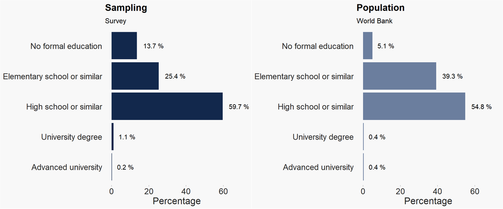

When it comes to education, the people in the sample have a higher share of no formal education compared to the general population.

## Employment

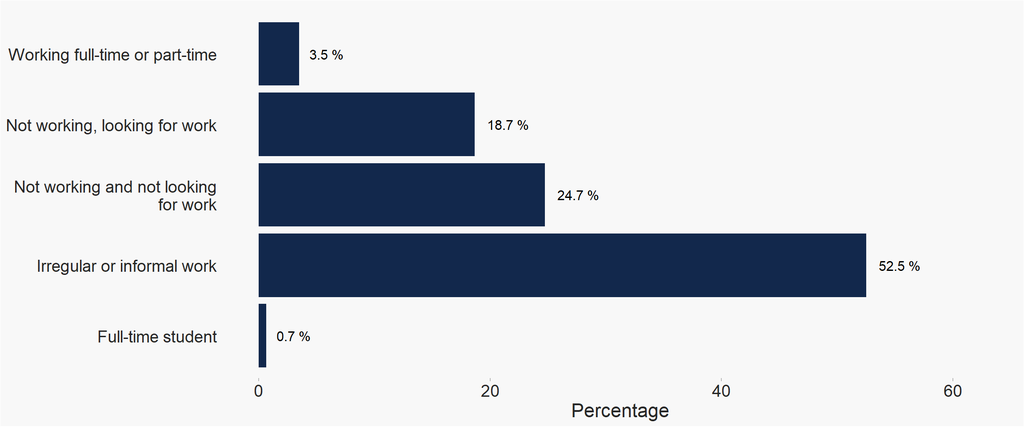

Employment around the clinics is dominated by irregular and informal work. Data on employment for the area or the country as a whole could not be sourced.

## Relationship with Red Cross

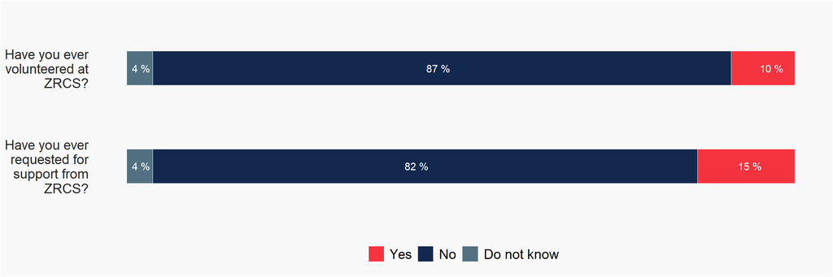

Overall, the numbers of people in the sample who requested support and as well as those who volunteered are in a range that can be expected from the general population. ***

# Results

## Score distribution

*Distribution of mean scores for values and competencies per demographic questions*

When looking at the average raw scores for all the competencies and value question, we can produce a number of breakdowns using the presented demographic variables.

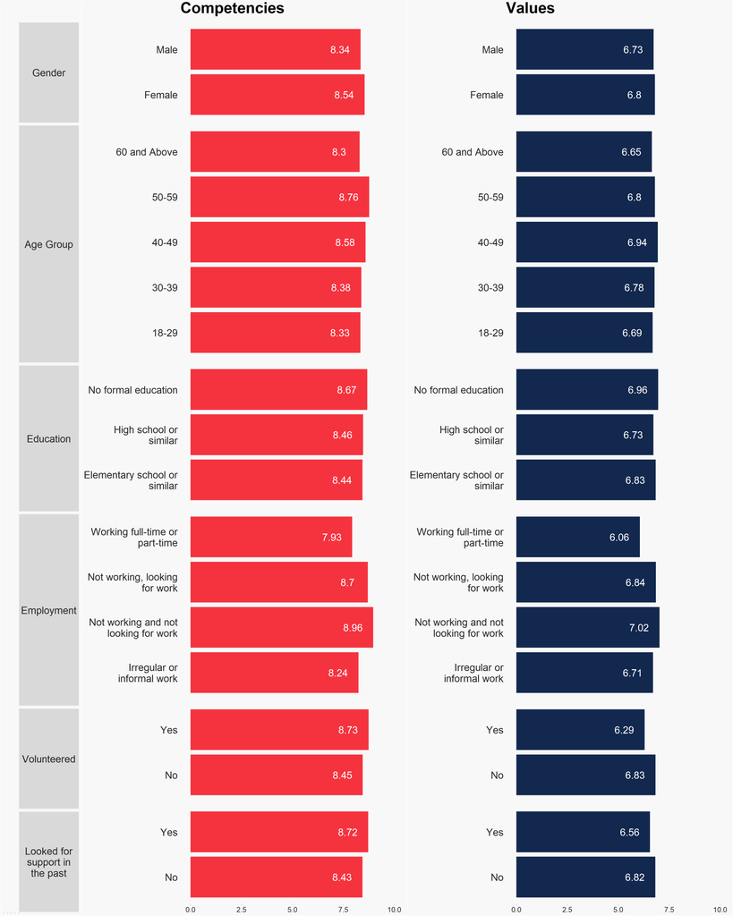

Upon analyzing the data, we observe that there are not major variations in the results based on age, gender, previous beneficiary status or volunteer status. The largest variations we see for the employment status variable. However, we do not have data on employment status for the survey location, which we could use for post-stratification.

## Overall score

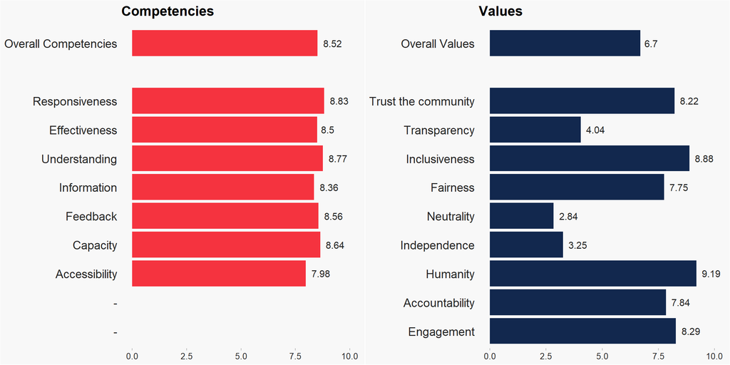

## Score per profile

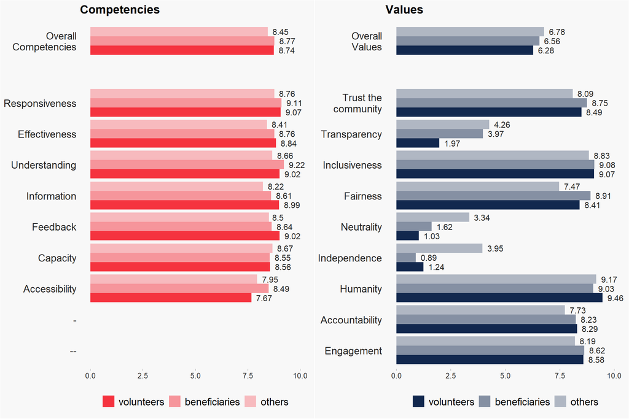

Download Summary Excel File

## Significance testing

When checking for significant differences between the groups we use a t-test to compare means of the competency and value questions, for all the questions, the differences in the results for the three groups indeed not significant for most variables due to the small sample size. The table shows whether a results for beneficiaries, volunteers and others are significantly different form each other. We used a 95% confidence level and corrected the p-values using a multiple comparisons correction. Questions on neutrality and transparency are significantly different for two of the three groups.

| Dimension | Drivers | Volunteer-Other | Volunteer-Beneficiary | Benficiary-Other |
| --- | --- | --- | --- | --- |
| Competency | Responsiveness | No | No | No |
| Competency | Effectiveness | No | No | No |
| Competency | Understanding | No | No | Yes |
| Competency | Accessibility | No | No | No |
| Competency | Feedback | No | No | No |
| Competency | Information | Yes | No | No |
| Competency | Capacity | No | No | No |
| Value | Fairness | No | No | Yes |
| Value | Humanity | No | No | No |
| Value | Inclusiveness | No | No | No |
| Value | Engagement | No | No | No |
| Value | Trust the community | No | No | No |
| Value | Accountability | No | No | No |
| Value | Transparency | Yes | Yes | No |
| Value | Independence | Yes | No | Yes |
| Value | Neutrality | Yes | No | Yes |